# Storm Data Analysis

Seth Dobrin

January 15th, 2016

## Synopsis

This report analyses storm and natural disaster data from the United States leveraging NOAA data collected from 1950 thru 2011. Here we focus on the public health the economic impact caused by different types of events. This analysis finds that tornados have the most significant impact on both public health and economics.

## Data Processing

Load and preprocess the data Store the URL for data

```r
fileURL <- c("https://d396qusza40orc.cloudfront.net/repdata%2Fdata%2FstormData.csv.bz2")
docURL <- c("https://d396qusza40orc.cloudfront.net/repdata%2Fpeer2_doc%2Fpd01016005curr.pdf")
faqURL <- c("https://d396qusza40orc.cloudfront.net/repdata%2Fpeer2_doc%2FNCDC%20Storm%20Events-FAQ%20Page.pdf")
```

Store filenames and paths as varriables

```r
fileName <- "~/GitHub/RepData/PA_2/repdata-data-stormData.csv"
zipFileName <- "~/GitHub/RepData/PA_2/repdata-data-stormData.csv.bz2"
docFileName <- "~/GitHub/RepData/PA_2/repdata-peer2_doc-pd01016005curr.pdf"
faqFileName <- "~/GitHub/RepData/PA_2/repdata-peer2_doc-NCDC Storm Events-FAQ Page.pdf"
```

Check to see if file exists. Download and extract only if it does not

```r
library(R.utils, quietly = TRUE)
if (!file.exists(fileName)) {
    download.file(fileURL, destfile = zipFileName, method = "curl")
    bunzip2(file = zipFileName, fileName)
    date = Sys.Date()
}
```

Create data frame, reduce the complexity of the data by subsetting only the data needed for this report. Rename columns

```r
library(dplyr)
stormData <- read.csv(fileName, na.strings = " ")
stormData <- subset(stormData, select = c("EVTYPE", "FATALITIES", "INJURIES",
    "PROPDMG", "CROPDMG"))
stormData[is.na(stormData)] <- 0
colnames(stormData) <- c("Event", "Fatalities", "Injuries", "PropDmg", "CropDmg")
propDmg <- summarize(group_by(stormData, Event), sum(PropDmg))
colnames(propDmg) <- c("Event", "PropDmg")
cropDmg <- summarize(group_by(stormData, Event), sum(CropDmg))
colnames(cropDmg) <- c("Event", "CropDmg")
fatal <- summarize(group_by(stormData, Event), sum(Fatalities))
colnames(fatal) <- c("Event", "Fatalities")
injury <- summarize(group_by(stormData, Event), sum(Injuries))
colnames(injury) <- c("Event", "Injuries")
```

Order data frames and get summary assesments for reporting and further analysis.

```r
summaryData <- Reduce(function(...) merge(..., all = TRUE), list(propDmg, cropDmg,
    fatal, injury))
top5PropDmg <- propDmg[with(propDmg, order(-PropDmg)), ][1:5, ]  # order data frame and subset top 5
top5CropDmg <- cropDmg[with(cropDmg, order(-CropDmg)), ][1:5, ]  # order data frame and subset top 5
top5Fatal <- fatal[with(fatal, order(-Fatalities)), ][1:5, ]  # order data frame and subset top 5
top5Injury <- injury[with(injury, order(-Injuries)), ][1:5, ]  # order data frame and subset top 5
economic <- Reduce(function(...) merge(..., all = TRUE), list(top5PropDmg, top5CropDmg))
economic <- mutate(economic, TotalDmg = (economic$PropDmg + economic$CropDmg))
health <- Reduce(function(...) merge(..., all = TRUE), list(top5Fatal, top5Injury))
health <- mutate(health, TotalHealth = (health$Fatalities + health$Injuries))
```

## Results

Across the United States, which types of events are most harmful with respect to population health?

```r
health[with(health, order(-TotalHealth)), ][1:5, ]
```

```
##            Event Fatalities Injuries TotalHealth
## 6        TORNADO       5633    91346       96979
## 1 EXCESSIVE HEAT       1903     6525        8428
## 5      LIGHTNING        816     5230        6046
## 2    FLASH FLOOD        978       NA          NA
## 3          FLOOD         NA     6789          NA
```

Table 1: Summary assesments of the top public health impacts

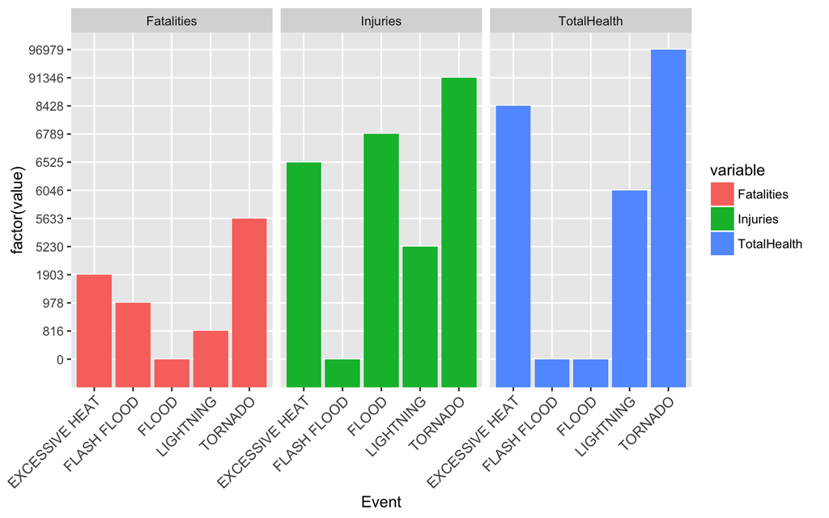

```r
healthData <- melt(topHealth, id = "Event")
healthData[is.na(healthData)] <- 0
ggplot(healthData, aes(x = Event, y = factor(value), fill = variable)) + geom_bar(stat = "identity",
    position = "identity") + facet_wrap(~variable) + theme(axis.text.x = element_text(size = 10,
    angle = 45, hjust = 1, vjust = 1))
```

Figure 1: Representation of the public health data showing the events contributing to injuries, fatalities and total (injuries + fatalities) health impact.

Across the United States, which types of events have the greatest economic consequences?

```r
economic[with(economic, order(-TotalDmg)), ][1:5, ]
```

```
##         Event   PropDmg  CropDmg TotalDmg
## 5     TORNADO 3212258.2 100018.5  3312277
## 1 FLASH FLOOD 1420124.6 179200.5  1599325
## 6   TSTM WIND 1335965.6 109202.6  1445168
## 2       FLOOD  899938.5 168037.9  1067976
## 3        HAIL        NA 579596.3       NA
```

Table 2: Summary assesments of economic impacts

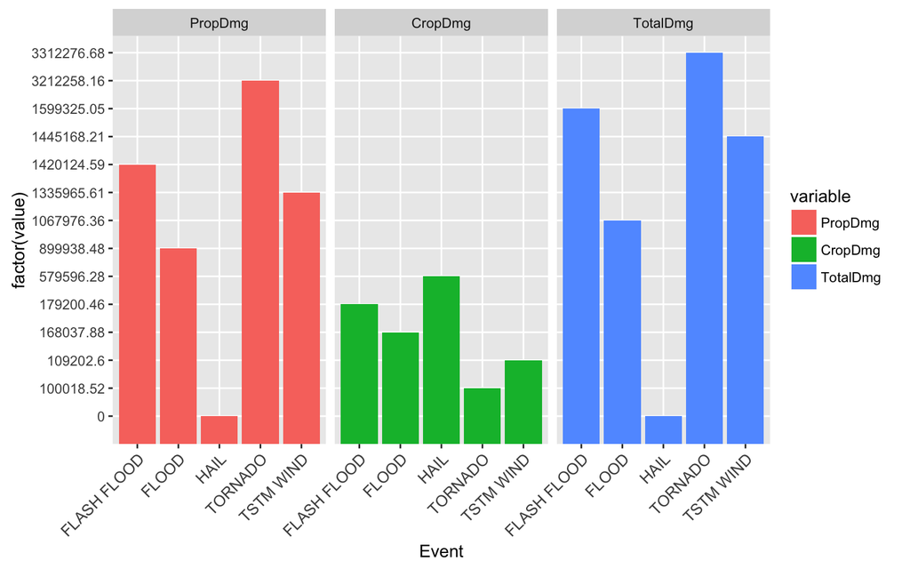

```r
library(data.table)
library(ggplot2)
damageData <- melt(topEconomic, id = "Event")
damageData[is.na(damageData)] <- 0
ggplot(damageData, aes(x = Event, y = factor(value), fill = variable)) + geom_bar(stat = "identity",
    position = "identity") + facet_wrap(~variable) + theme(axis.text.x = element_text(size = 10,
    angle = 45, hjust = 1, vjust = 1))
```

Figure 2: Representation of the economic data showing the events contributing to property damage, crop damage and total (property damage + crop damage) economic impact.